# Grocery Store Coupon Campaign EDA

D’Ette Wagar

2024-05-12

### This project explores a data set called “The Complete Journey,” which was developed by Brad Boehmke and Steven M. Mortimer. It contains transaction level data from a group of 2,469 frequent shoppers at a grocery store. It includes all of the shopper’s transactional data, along with their demographic information and information relating to marketing campaign information, including coupons they received and store promotions.

### I am interested in exploring how different coupon campaigns influence shoppers buying decisions.

```r
# Load R packages
install.packages("dplyr")
library(dplyr)
install.packages("tidyverse")
library(tidyverse)
install.packages("readr")
library(readr)
install.packages("tidyselect")
library(tidyselect)
install.packages("reshape2")
library(reshape2)
```

```r
install.packages("ggplot2")
library(ggplot2)
install.packages("readxl")
library(readxl)
install.packages("RColorBrewer")
library(RColorBrewer)
install.packages("corrplot")
library(corrplot)
install.packages("completejourney")
library(completejourney)
install.packages("remotes")
remotes::install_github("bradleyboehmke/completejourney")
# Let's begin by just getting an idea of what is in the data.

# Get coupon data
coupons_df <- coupons
glimpse(coupons_df)
```

```
## Rows: 116,204
## Columns: 3
## $ coupon_upc  <chr> "10000085207", "10000085207", "10000085207", "10000085207"…
## $ product_id  <chr> "9676830", "9676943", "9676944", "9676947", "9677008", "96…
## $ campaign_id <chr> "26", "26", "26", "26", "26", "26", "26", "26", "26", "26"…
```

```r
# Get product data
products_df <- products
glimpse(products_df)
```

```
## Rows: 92,331
## Columns: 7
## $ product_id       <chr> "25671", "26081", "26093", "26190", "26355", "26426",…
## $ manufacturer_id  <chr> "2", "2", "69", "69", "69", "69", "69", "69", "69", "…
## $ department       <chr> "GROCERY", "MISCELLANEOUS", "PASTRY", "GROCERY", "GRO…
## $ brand            <fct> National, National, Private, Private, Private, Privat…
## $ product_category <chr> "FRZN ICE", NA, "BREAD", "FRUIT - SHELF STABLE", "COO…
## $ product_type     <chr> "ICE - CRUSHED/CUBED", NA, "BREAD:ITALIAN/FRENCH", "A…
## $ package_size     <chr> "22 LB", NA, NA, "50 OZ", "14 OZ", "2.5 OZ", "16 OZ",…
```

```r
# Get demographics data
demo_df <- demographics
glimpse(demo_df)
```

```
## Rows: 801
## Columns: 8
## $ household_id   <chr> "1", "1001", "1003", "1004", "101", "1012", "1014", "10…
## $ age            <ord> 65+, 45-54, 35-44, 25-34, 45-54, 35-44, 45-54, 45-54, 4…
## $ income         <ord> 35-49K, 50-74K, 25-34K, 15-24K, Under 15K, 35-49K, 15-2…
## $ home_ownership <ord> Homeowner, Homeowner, NA, NA, Homeowner, NA, NA, Homeow…
## $ marital_status <ord> Married, Unmarried, Unmarried, Unmarried, Married, Marr…
## $ household_size <ord> 2, 1, 1, 1, 4, 5+, 4, 1, 5+, 2, 5+, 4, 2, 1, 5+, 1, 1, …
## $ household_comp <ord> 2 Adults No Kids, 1 Adult No Kids, 1 Adult No Kids, 1 A…
## $ kids_count     <ord> 0, 0, 0, 0, 2, 3+, 2, 0, 3+, 0, 3+, 2, 0, 0, 3+, 0, 0, …
```

```r
# Get tramsaction data
transactions_df <- get_transactions()
glimpse(transactions_df)
```

```
## Rows: 1,469,307
## Columns: 11
## $ household_id          <chr> "900", "900", "1228", "906", "906", "906", "906"…
## $ store_id              <chr> "330", "330", "406", "319", "319", "319", "319",…
## $ basket_id             <chr> "31198570044", "31198570047", "31198655051", "31…
## $ product_id            <chr> "1095275", "9878513", "1041453", "1020156", "105…
## $ quantity              <dbl> 1, 1, 1, 1, 2, 1, 1, 1, 1, 1, 1, 1, 1, 1, 1, 1, …
## $ sales_value           <dbl> 0.50, 0.99, 1.43, 1.50, 2.78, 5.49, 1.50, 1.88, …
## $ retail_disc           <dbl> 0.00, 0.10, 0.15, 0.29, 0.80, 0.50, 0.29, 0.21, …
## $ coupon_disc           <dbl> 0, 0, 0, 0, 0, 0, 0, 0, 0, 0, 0, 0, 0, 0, 0, 0, …
## $ coupon_match_disc     <dbl> 0, 0, 0, 0, 0, 0, 0, 0, 0, 0, 0, 0, 0, 0, 0, 0, …
## $ week                  <int> 1, 1, 1, 1, 1, 1, 1, 1, 1, 1, 1, 1, 1, 1, 1, 1, …
## $ transaction_timestamp <dttm> 2017-01-01 06:53:26, 2017-01-01 07:10:28, 2017-…
```

### Let’s try to determine whether campaigns were successful in driving up sales in the products they promoted.

```r
# Display information on coupon campaigns

coup_camp_df <- campaign_descriptions
print.data.frame(coup_camp_df)
```

```
##    campaign_id campaign_type start_date   end_date
## 1            1        Type B 2017-03-03 2017-04-09
## 2            2        Type B 2017-03-08 2017-04-09
## 3            3        Type C 2017-03-13 2017-05-08
## 4            4        Type B 2017-03-29 2017-04-30
## 5            5        Type B 2017-04-03 2017-05-07
## 6            6        Type C 2017-04-19 2017-05-21
## 7            7        Type B 2017-04-24 2017-05-28
## 8            8        Type A 2017-05-08 2017-06-25
## 9            9        Type B 2017-05-31 2017-07-02
## 10          10        Type B 2017-06-28 2017-07-30
## 11          11        Type B 2017-07-12 2017-08-27
## 12          12        Type B 2017-07-12 2017-08-13
## 13          13        Type A 2017-08-08 2017-09-24
## 14          14        Type C 2017-09-04 2017-11-08
## 15          15        Type C 2017-09-20 2018-02-28
## 16          16        Type B 2017-10-04 2017-11-05
## 17          17        Type B 2017-10-18 2017-11-19
## 18          18        Type A 2017-10-30 2017-12-24
## 19          19        Type B 2017-11-15 2017-12-17
## 20          20        Type C 2017-11-27 2018-02-05
## 21          21        Type B 2017-12-06 2018-01-07
## 22          22        Type B 2017-12-06 2018-01-07
## 23          23        Type B 2017-12-28 2018-02-04
## 24          24        Type C 2016-11-14 2017-01-16
## 25          25        Type B 2016-12-06 2017-02-05
## 26          26        Type B 2016-12-28 2017-02-19
## 27          27        Type A 2017-02-08 2017-03-26
```

### When the campaign type is B or C, the customer receives all of the corresponding coupons in the coupon table. My first 3 analyses will focus on campaigns of these types, namely: Campaigns 14, 10, and 16.

## Campaign 14

### The first campaign I will examine is campaign 14. Since it ran from 9-4-2017 to 11-8-2017, I will be able to compare the transaction data on applicable products from during the campaign to data on the same products on periods before and after the campaign.

```r
# Let's look at the coupon data for campaign ID 14

# We can see that there are number of different product_ids associated with
# the various coupon_upcs attached to this campaign
coup_df <- coupons_df %>%
  select(campaign_id, product_id, coupon_upc) %>%
  group_by(campaign_id, coupon_upc) %>%
  filter(campaign_id == 14) %>%
  tally()

print.data.frame(coup_df)
```

```
##    campaign_id  coupon_upc   n
## 1           14 10000085433   3
## 2           14 50052110076  23
## 3           14 51111120076  34
## 4           14 51111124076  13
## 5           14 51111124078  13
## 6           14 51111131075  18
## 7           14 51111131077  18
## 8           14 52150000050  17
## 9           14 53620010028  76
## 10          14 54100010032  44
## 11          14 54100024032  42
## 12          14 54100027032  96
## 13          14 54589314175  37
## 14          14 54589314177  37
## 15          14 54589320576  12
## 16          14 54589320578  12
## 17          14 54589353176   2
## 18          14 54589353178   2
## 19          14 54589371155  40
## 20          14 54589371175  40
## 21          14 54589399250 164
## 22          14 54589399275 164
## 23          14 54589399276  52
## 24          14 54589399278  52
## 25          14 54800110055  42
## 26          14 54800140060   9
```

```r
# Now, we want to see which households participated in this campaign. From
# there, we will examine how this correlates to the spending of those
# households both before and after the campaign.

# View purchases made by participating households during campaign 14
cam14_redem_df <- coupon_redemptions %>%
  select(campaign_id, household_id, coupon_upc, redemption_date) %>%
  filter(campaign_id == 14)

glimpse(cam14_redem_df)
```

```
## Rows: 34
## Columns: 4
## $ campaign_id     <chr> "14", "14", "14", "14", "14", "14", "14", "14", "14", …
## $ household_id    <chr> "256", "636", "636", "1529", "888", "888", "888", "88"…
## $ coupon_upc      <chr> "54100027032", "54100027032", "54589399250", "54100027…
## $ redemption_date <date> 2017-09-06, 2017-09-06, 2017-09-06, 2017-09-08, 2017-…
```

```r
# Let's see how many sale items each household purchased during the sale
# period

# First, merge redemption data with coupon data
cam14_coup_df <- merge(coupons_df, cam14_redem_df,
                       by = c("campaign_id","coupon_upc"))

# Next, merge redemption/coupon data with transaction data from the
# campaign period
cam14_tran_df <- merge(cam14_coup_df, transactions_df,
                       by.x = c("household_id", "product_id"),
                       by.y = c("household_id", "product_id")) %>%
  select(household_id, product_id, quantity,
         redemption_date, transaction_timestamp) %>%
  filter(between(as.Date(transaction_timestamp), as.Date("2017-09-04"),
           as.Date("2017-11-08")),
         between(as.Date(redemption_date), as.Date("2017-09-04"),
           as.Date("2017-11-08")))

# Create a data file of the household IDs and product IDs that definitely
# have transactions within the campaign window. (Unfortunately, we cannot
# assume that all coupons in the redemption table have matches in the
# transaction table, and we want to make sure that we are not capturing
# transactions for any households that did not participate in the campaign.)
cam14_house_prod_df <- cam14_tran_df %>%
  distinct(household_id, product_id)

# Count the quantity of applicable products purchased during the campaign
# period per household
sum_cam14_tran_df <- cam14_tran_df %>%
  select(household_id, quantity) %>%
  group_by(household_id) %>%
  summarize(tot_quantity = sum(quantity))

# Normalize the quantity by determining quantity purchased per day;
# that way, we can accurately compare sales from before, during, and
# after the campaign period

# Get number of days in campaign
cam14_days <- as.numeric(difftime("2017-11-08", "2017-09-04", units = "days"))

print(cam14_days)
```

```
## [1] 65
```

```r
# Add the quantity per day field (norm_quantity) to the summary campaign
# data frame and add field showing period relative to campaign
sum_cam14_tran_df <- sum_cam14_tran_df %>%
  select(household_id, tot_quantity) %>%
  mutate(norm_quantity = (tot_quantity/cam14_days),
         per_rel_camp = "During",
         per_rel_num = 1)

print.data.frame(sum_cam14_tran_df)
```

```
##    household_id tot_quantity norm_quantity per_rel_camp per_rel_num
## 1          1142            2    0.03076923       During           1
## 2           127            1    0.01538462       During           1
## 3          1529            5    0.07692308       During           1
## 4          1764           12    0.18461538       During           1
## 5          2488            1    0.01538462       During           1
## 6          2489            3    0.04615385       During           1
## 7           256            7    0.10769231       During           1
## 8           464            1    0.01538462       During           1
## 9           472            1    0.01538462       During           1
## 10          560            6    0.09230769       During           1
## 11          588            9    0.13846154       During           1
## 12          600            5    0.07692308       During           1
## 13          636           15    0.23076923       During           1
## 14          641            1    0.01538462       During           1
## 15           88            2    0.03076923       During           1
## 16          888            8    0.12307692       During           1
## 17          982            1    0.01538462       During           1
```

```r
# Merge the redemption/coupon data with the transaction data from BEFORE
# the campaign period, and then merge that with the table of household
# IDs/product IDs that are participating in the campaign
pcam14_tran_df <- merge(cam14_coup_df, transactions_df,
                       by = c("household_id", "product_id")) %>%
  select(household_id, product_id, quantity, transaction_timestamp) %>%
  filter(as.Date(transaction_timestamp) < "2017-09-04")

pcam14_tran_df <- merge(pcam14_tran_df, cam14_house_prod_df,
                        by = c("household_id", "product_id"))

# Count the quantity of applicable products purchased before the campaign
# period per household
psum_cam14_tran_df <- pcam14_tran_df %>%
  select(household_id, quantity) %>%
  group_by(household_id) %>%
  summarize(tot_quantity = sum(quantity))

# Normalize the quantity value for the period before the campaign
pcam14_days <- as.numeric(difftime("2017-09-04", "2017-01-01", units = "days"))

print(pcam14_days)
```

```
## [1] 246
```

```r
# Add field to the summary campaign data frame showing the normalized
# quantity value, and add field showing period relative to campaign
psum_cam14_tran_df <- psum_cam14_tran_df %>%
  select(household_id, tot_quantity) %>%
  mutate(norm_quantity = (tot_quantity/pcam14_days),
         per_rel_camp = "Before",
         per_rel_num = 0)

print.data.frame(psum_cam14_tran_df)
```

```
##    household_id tot_quantity norm_quantity per_rel_camp per_rel_num
## 1          1142            1   0.004065041       Before           0
## 2          1529            7   0.028455285       Before           0
## 3          1764            8   0.032520325       Before           0
## 4          2488            2   0.008130081       Before           0
## 5          2489            1   0.004065041       Before           0
## 6           256            2   0.008130081       Before           0
## 7           560            1   0.004065041       Before           0
## 8           588            6   0.024390244       Before           0
## 9           636           49   0.199186992       Before           0
## 10           88            3   0.012195122       Before           0
## 11          888            8   0.032520325       Before           0
```

```r
# Merge the redemption/coupon data with the transaction data from AFTER
# the campaign period, and then merge that with the table of household
# IDs/product IDs that are participating in the campaign
acam14_tran_df <- merge(cam14_coup_df, transactions_df,
                       by = c("household_id", "product_id")) %>%
  select(household_id, product_id, quantity, transaction_timestamp) %>%
  filter(as.Date(transaction_timestamp) > "2017-11-08")

acam14_tran_df <- merge(acam14_tran_df, cam14_house_prod_df,
                        by = c("household_id", "product_id"))

# Count the quantity of applicable products purchased after the campaign
# period per household
asum_cam14_tran_df <- acam14_tran_df %>%
  select(household_id, quantity) %>%
  group_by(household_id) %>%
  summarize(tot_quantity = sum(quantity))

print.data.frame(asum_cam14_tran_df)
```

```
##   household_id tot_quantity
## 1         1529            3
## 2          636            5
```

```r
# Normalize the quantity value for the period after the campaign
acam14_days <- as.numeric(difftime("2018-01-01", "2017-11-08", units = "days"))

print(acam14_days)
```

```
## [1] 54
```

```r
# Add field to the summary campaign data frame showing the normalized
# quantity value, and add field showing period relative to campaign
asum_cam14_tran_df <- asum_cam14_tran_df %>%
  select(household_id, tot_quantity) %>%
  mutate(norm_quantity = (tot_quantity/acam14_days),
         per_rel_camp = "After",
         per_rel_num = 2)

print.data.frame(asum_cam14_tran_df)
```

```
##   household_id tot_quantity norm_quantity per_rel_camp per_rel_num
## 1         1529            3    0.05555556        After           2
## 2          636            5    0.09259259        After           2
```

### We have the rates at which the campaign products were purchased (quantity/day) for the periods before the campaign, during the campaign, and after the campaign. Now, let’s merge that data and observe it in a bar chart. From there, we can see if there are any statistical correlations to be drawn.

```r
#Join campaign transaction data with data from before the campaign
all_cam14_tran_df <- rbind(sum_cam14_tran_df, psum_cam14_tran_df)

print.data.frame(all_cam14_tran_df)
```

```
##    household_id tot_quantity norm_quantity per_rel_camp per_rel_num
## 1          1142            2   0.030769231       During           1
## 2           127            1   0.015384615       During           1
## 3          1529            5   0.076923077       During           1
## 4          1764           12   0.184615385       During           1
## 5          2488            1   0.015384615       During           1
## 6          2489            3   0.046153846       During           1
## 7           256            7   0.107692308       During           1
## 8           464            1   0.015384615       During           1
## 9           472            1   0.015384615       During           1
## 10          560            6   0.092307692       During           1
## 11          588            9   0.138461538       During           1
## 12          600            5   0.076923077       During           1
## 13          636           15   0.230769231       During           1
## 14          641            1   0.015384615       During           1
## 15           88            2   0.030769231       During           1
## 16          888            8   0.123076923       During           1
## 17          982            1   0.015384615       During           1
## 18         1142            1   0.004065041       Before           0
## 19         1529            7   0.028455285       Before           0
## 20         1764            8   0.032520325       Before           0
## 21         2488            2   0.008130081       Before           0
## 22         2489            1   0.004065041       Before           0
## 23          256            2   0.008130081       Before           0
## 24          560            1   0.004065041       Before           0
## 25          588            6   0.024390244       Before           0
## 26          636           49   0.199186992       Before           0
## 27           88            3   0.012195122       Before           0
## 28          888            8   0.032520325       Before           0
```

```r
#Join campaign transaction data with data from after the campaign
all_cam14_tran_df <- rbind(all_cam14_tran_df, asum_cam14_tran_df)

print.data.frame(all_cam14_tran_df)
```

```
##    household_id tot_quantity norm_quantity per_rel_camp per_rel_num
## 1          1142            2   0.030769231       During           1
## 2           127            1   0.015384615       During           1
## 3          1529            5   0.076923077       During           1
## 4          1764           12   0.184615385       During           1
## 5          2488            1   0.015384615       During           1
## 6          2489            3   0.046153846       During           1
## 7           256            7   0.107692308       During           1
## 8           464            1   0.015384615       During           1
## 9           472            1   0.015384615       During           1
## 10          560            6   0.092307692       During           1
## 11          588            9   0.138461538       During           1
## 12          600            5   0.076923077       During           1
## 13          636           15   0.230769231       During           1
## 14          641            1   0.015384615       During           1
```

[output cut: 16 more lines]

### Display purchase rate for each household by time period relative to campaign period

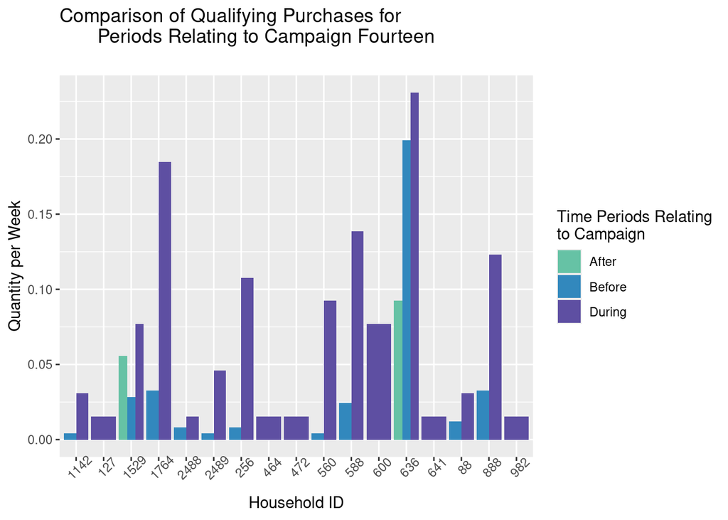

```r
# Now let's see if there is any relationship between the variables
# norm_quantity and per_rel_camp (using per_rel_id because it is numeric).
# We will find the correlation and test the null hypothesis that the two values # are not related to one another.
cor.test(all_cam14_tran_df$norm_quantity,
         all_cam14_tran_df$per_rel_num)
```

```
##
##  Pearson's product-moment correlation
##
## data:  all_cam14_tran_df$norm_quantity and all_cam14_tran_df$per_rel_num
## t = 1.5899, df = 28, p-value = 0.1231
## alternative hypothesis: true correlation is not equal to 0
## 95 percent confidence interval:
##  -0.08089754  0.58715677
## sample estimates:
##       cor
## 0.2877584
```

### As the statistical analysis shows, there does not seem to be a correlation between the effects of the campaign and the spending habits of the households who purchased products included in the campaign, in the sense that households did not favor a time period (before, during, or after the campaign) to purchase campaign products. The correlation coefficient is .288, with values approaching 1 indicating the closest correlation. Furthermore, we can reject the hypothesis that there is NO correlation between the variables of quantity purchased and time period purchased (before, during, or after campaign) if the probablity (p value) is smaller than .05 (5%). We can see here that the probability is .123. It is not particularly high, but it is not low enough to reject the hypothesis that there is no correlation between the variables. Unfortunately, we have no statistical evidence that the rate of quantities purchased is related to the variable that we have defined as before, during, or after the campaign period.

## Campaign 10

### The second campaign I will examine is campaign 10. It took place more toward the middle of the year, running from 6-28-2017 to 7-30-2017.

```r
# Let's look at the coupon data for campaign ID 10

# We can see that there are number of different product_ids associated with
# the various coupon_upcs attached to this campaign
coup_df <- coupons_df %>%
  select(campaign_id, product_id, coupon_upc) %>%
  group_by(campaign_id, coupon_upc) %>%
  filter(campaign_id == 10) %>%
  tally()

print.data.frame(coup_df)
```

```
##    campaign_id  coupon_upc  n
## 1           10 10000085370  4
## 2           10 10000089072  5
## 3           10 50813700076 63
## 4           10 50813713084  7
## 5           10 51300010013 10
## 6           10 51500059033 94
## 7           10 53600000082 69
## 8           10 53700048182 53
## 9           10 54110030074  7
## 10          10 54589314178  9
## 11          10 55220010013 49
## 12          10 57007444182  6
## 13          10 57109130055  3
## 14          10 57410101082 14
```

```r
# Now, we want to see which households participated in this campaign. From
# there, we will examine how this correlates to the spending of those
# households both before and after the campaign.

# View purchases made by participating households during campaign 10
cam10_redem_df <- coupon_redemptions %>%
  select(campaign_id, household_id, coupon_upc, redemption_date) %>%
  filter(campaign_id == 10)

glimpse(cam10_redem_df)
```

```
## Rows: 15
## Columns: 4
## $ campaign_id     <chr> "10", "10", "10", "10", "10", "10", "10", "10", "10", …
## $ household_id    <chr> "2240", "2280", "574", "605", "605", "1541", "2124", "…
## $ coupon_upc      <chr> "53600000082", "53700048182", "10000085370", "10000085…
## $ redemption_date <date> 2017-07-01, 2017-07-01, 2017-07-03, 2017-07-04, 2017-…
```

```r
# Let's see how many sale items each household purchased during the sale
# period

# First, merge redemption data with coupon data
cam10_coup_df <- merge(coupons_df, cam10_redem_df,
                       by = c("campaign_id","coupon_upc"))

# Next, merge redemption/coupon data with transaction data from the
# campaign period
cam10_tran_df <- merge(cam10_coup_df, transactions_df,
                       by = c("household_id", "product_id")) %>%
  select(household_id, product_id, quantity,
         redemption_date, transaction_timestamp) %>%
  filter(between(as.Date(transaction_timestamp), as.Date("2017-06-28"),
           as.Date("2017-07-30")),
         between(as.Date(redemption_date), as.Date("2017-06-28"),
           as.Date("2017-07-30")))

# Create a data file of the household IDs and product IDs that definitely
# have transactions within the campaign window. (Unfortunately, we cannot
# assume that all coupons in the redemption table have matches in the
# transaction table, and we want to make sure that we are not capturing
# transactions for any households that did not participate in the campaign.)
cam10_house_prod_df <- cam10_tran_df %>%
  distinct(household_id, product_id)

# Count the quantity of applicable products purchased during the campaign
# period per household
sum_cam10_tran_df <- cam10_tran_df %>%
  select(household_id, quantity) %>%
  group_by(household_id) %>%
  summarize(tot_quantity = sum(quantity))

# Normalize the quantity by determining quantity purchased per day;
# that way, we can accurately compare sales from before, during, and
# after the campaign period

# Get number of days in campaign
cam10_days <- as.numeric(difftime("2017-07-30", "2017-06-28", units = "days"))

print(cam10_days)
```

```
## [1] 32
```

```r
# Add the quantity per day field (norm_quantity) to the summary campaign
# data frame and add field showing period relative to campaign
sum_cam10_tran_df <- sum_cam10_tran_df %>%
  select(household_id, tot_quantity) %>%
  mutate(norm_quantity = (tot_quantity/cam10_days),
         per_rel_camp = "During",
         per_rel_num = 1)

print.data.frame(sum_cam10_tran_df)
```

```
##   household_id tot_quantity norm_quantity per_rel_camp per_rel_num
## 1         1710            2       0.06250       During           1
## 2         2124            3       0.09375       During           1
## 3         2240            3       0.09375       During           1
## 4         2280            3       0.09375       During           1
## 5          605            6       0.18750       During           1
## 6          982            1       0.03125       During           1
```

```r
# Merge the redemption/coupon data with the transaction data from BEFORE
# the campaign period, and then merge that with the table of household
# IDs/product IDs that are participating in the campaign
pcam10_tran_df <- merge(cam10_coup_df, transactions_df,
                       by = c("household_id", "product_id")) %>%
  select(household_id, product_id, quantity, transaction_timestamp) %>%
  filter(as.Date(transaction_timestamp) < "2017-06-28")

pcam10_tran_df <- merge(pcam10_tran_df, cam10_house_prod_df,
                        by = c("household_id", "product_id"))

# Count the quantity of applicable products purchased before the campaign
# period per household
psum_cam10_tran_df <- pcam10_tran_df %>%
  select(household_id, quantity) %>%
  group_by(household_id) %>%
  summarize(tot_quantity = sum(quantity))

# Normalize the quantity value for the period before the campaign
pcam10_days <- as.numeric(difftime("2017-06-28", "2017-01-01", units = "days"))

print(pcam10_days)
```

```
## [1] 178
```

```r
# Add field to the summary campaign data frame showing the normalized
# quantity value, and add field showing period relative to campaign
psum_cam10_tran_df <- psum_cam10_tran_df %>%
  select(household_id, tot_quantity) %>%
  mutate(norm_quantity = (tot_quantity/pcam10_days),
         per_rel_camp = "Before",
         per_rel_num = 0)

print.data.frame(psum_cam10_tran_df)
```

```
##   household_id tot_quantity norm_quantity per_rel_camp per_rel_num
## 1         1710            2    0.01123596       Before           0
## 2         2124           14    0.07865169       Before           0
## 3         2240            4    0.02247191       Before           0
## 4         2280            3    0.01685393       Before           0
## 5          605            8    0.04494382       Before           0
```

```r
# Merge the redemption/coupon data with the transaction data from AFTER
# the campaign period, and then merge that with the table of household
# IDs/product IDs that are participating in the campaign
acam10_tran_df <- merge(cam10_coup_df, transactions_df,
                       by = c("household_id", "product_id")) %>%
  select(household_id, product_id, quantity, transaction_timestamp) %>%
  filter(as.Date(transaction_timestamp) > "2017-07-30")

acam10_tran_df <- merge(acam10_tran_df, cam10_house_prod_df,
                        by = c("household_id", "product_id"))

# Count the quantity of applicable products purchased after the campaign
# period per household
asum_cam10_tran_df <- acam10_tran_df %>%
  select(household_id, quantity) %>%
  group_by(household_id) %>%
  summarize(tot_quantity = sum(quantity))

print.data.frame(asum_cam10_tran_df)
```

```
##   household_id tot_quantity
## 1         2124           10
## 2         2280            3
```

```r
# Normalize the quantity value for the period after the campaign
acam10_days <- as.numeric(difftime("2018-01-01", "2017-07-30", units = "days"))

print(acam10_days)
```

```
## [1] 155
```

```r
# Add field to the summary campaign data frame showing the normalized
# quantity value, and add field showing period relative to campaign
asum_cam10_tran_df <- asum_cam10_tran_df %>%
  select(household_id, tot_quantity) %>%
  mutate(norm_quantity = (tot_quantity/acam10_days),
         per_rel_camp = "After",
         per_rel_num = 2)

print.data.frame(asum_cam10_tran_df)
```

```
##   household_id tot_quantity norm_quantity per_rel_camp per_rel_num
## 1         2124           10    0.06451613        After           2
## 2         2280            3    0.01935484        After           2
```

### We have the rates at which the campaign products were purchased (quantity/day) for the periods before the campaign, during the campaign, and after the campaign. Now, let’s merge that data and observe it in a bar chart. From there, we can see if there are any statistical correlations to be drawn.

```r
# Join campaign transaction data with data from before the campaign
all_cam10_tran_df <- rbind(sum_cam10_tran_df, psum_cam10_tran_df)

print.data.frame(all_cam10_tran_df)
```

```
##    household_id tot_quantity norm_quantity per_rel_camp per_rel_num
## 1          1710            2    0.06250000       During           1
## 2          2124            3    0.09375000       During           1
## 3          2240            3    0.09375000       During           1
## 4          2280            3    0.09375000       During           1
## 5           605            6    0.18750000       During           1
## 6           982            1    0.03125000       During           1
## 7          1710            2    0.01123596       Before           0
## 8          2124           14    0.07865169       Before           0
## 9          2240            4    0.02247191       Before           0
## 10         2280            3    0.01685393       Before           0
## 11          605            8    0.04494382       Before           0
```

```r
# Join campaign transaction data with data from after the campaign
all_cam10_tran_df <- rbind(all_cam10_tran_df, asum_cam10_tran_df)

print.data.frame(all_cam10_tran_df)
```

```
##    household_id tot_quantity norm_quantity per_rel_camp per_rel_num
## 1          1710            2    0.06250000       During           1
## 2          2124            3    0.09375000       During           1
## 3          2240            3    0.09375000       During           1
## 4          2280            3    0.09375000       During           1
## 5           605            6    0.18750000       During           1
## 6           982            1    0.03125000       During           1
## 7          1710            2    0.01123596       Before           0
## 8          2124           14    0.07865169       Before           0
## 9          2240            4    0.02247191       Before           0
## 10         2280            3    0.01685393       Before           0
## 11          605            8    0.04494382       Before           0
## 12         2124           10    0.06451613        After           2
## 13         2280            3    0.01935484        After           2
```

### Display purchase rate for each household by time period relative to campaign period

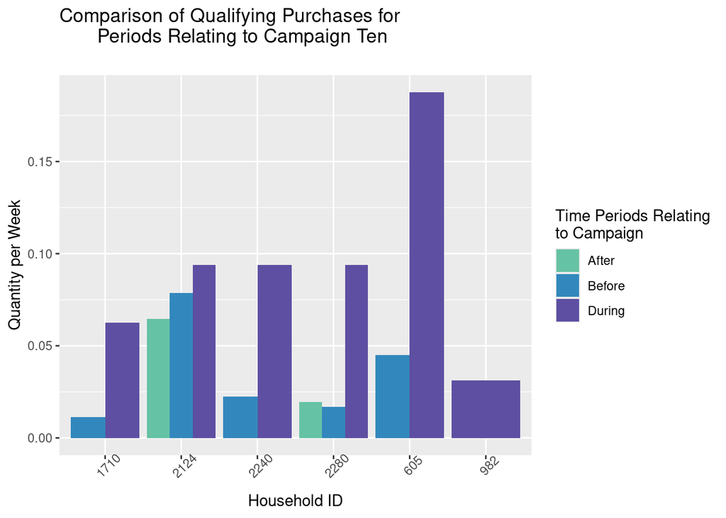

```r
# Now let's see if there is any relationship between the variables
# norm_quantity and per_rel_camp (using per_rel_id because it is
# numeric). We will find the correlation and test the null hypothesis
# that the two values are not related to one another.
cor.test(all_cam10_tran_df$norm_quantity,
         all_cam10_tran_df$per_rel_num)
```

```
##
##  Pearson's product-moment correlation
##
## data:  all_cam10_tran_df$norm_quantity and all_cam10_tran_df$per_rel_num
## t = 0.80035, df = 11, p-value = 0.4405
## alternative hypothesis: true correlation is not equal to 0
## 95 percent confidence interval:
##  -0.3633709  0.6956523
## sample estimates:
##       cor
## 0.2345802
```

### As the statistical analysis shows, there also does not seem to be a correlation between the effects of campaign ten and the spending habits of the households who purchased products included in the campaign. In fact, there seems to be even less of a correlation than there was in campaign fourteen, and the p value of .44 indicates that we are a long way from being able to reject the hypothesis that there is no relationship between the variables. This result is not surprising, considering the fact that there are even fewer households involved in this campaign than there were in campaign 14 (i.e., the population is smaller).

## Campaign 16

```r
# Now, let's look at the coupon data for campaign ID 16

# We can see that there are number of different product_ids associated with
# the various coupon_upcs attached to this campaign
coup_df <- coupons_df %>%
  select(campaign_id, product_id, coupon_upc) %>%
  group_by(campaign_id, coupon_upc) %>%
  filter(campaign_id == 16) %>%
  tally()

print.data.frame(coup_df)
```

```
##    campaign_id  coupon_upc   n
## 1           16 10000085436  26
## 2           16 10000085482  21
## 3           16 50076613076  23
## 4           16 50099700082 349
## 5           16 51254600033   2
## 6           16 52270011076 428
## 7           16 53500000076  19
## 8           16 53600030082  30
## 9           16 53700048076  58
## 10          16 55310000076  32
## 11          16 56382410076   4
## 12          16 57124921076  23
## 13          16 57418211676  10
```

```r
# We want to see which households participated in this campaign. From
# there, we will examine how this correlates to the spending of those
# households both before and after the campaign.

# View purchases made by participating households during campaign 16
cam16_redem_df <- coupon_redemptions %>%
  select(campaign_id, household_id, coupon_upc, redemption_date) %>%
  filter(campaign_id == 16)

glimpse(cam16_redem_df)
```

```
## Rows: 43
## Columns: 4
## $ campaign_id     <chr> "16", "16", "16", "16", "16", "16", "16", "16", "16", …
## $ household_id    <chr> "1850", "113", "1491", "1505", "1989", "1687", "1687",…
## $ coupon_upc      <chr> "10000085482", "53500000076", "10000085436", "53500000…
## $ redemption_date <date> 2017-10-04, 2017-10-05, 2017-10-06, 2017-10-06, 2017-…
```

```r
# Let's see how many sale items each household purchased during the sale
# period

# First, merge redemption data with coupon data
cam16_coup_df <- merge(coupons_df, cam16_redem_df,
                       by = c("campaign_id","coupon_upc"))

# Next, merge redemption/coupon data with transaction data from the
# campaign period
cam16_tran_df <- merge(cam16_coup_df, transactions_df,
                       by = c("household_id", "product_id")) %>%
  select(household_id, product_id, quantity,
         redemption_date, transaction_timestamp) %>%
  filter(between(as.Date(transaction_timestamp), as.Date("2017-10-04"),
           as.Date("2017-11-05")),
         between(as.Date(redemption_date), as.Date("2017-10-04"),
           as.Date("2017-11-05")))

# Create a data file of the household IDs and product IDs that definitely
# have transactions within the campaign window. (Unfortunately, we cannot
# assume that all coupons in the redemption table have matches in the
# transaction table, and we want to make sure that we are not capturing
# transactions for any households that did not participate in the campaign.)
cam16_house_prod_df <- cam16_tran_df %>%
  distinct(household_id, product_id)

# Count the quantity of applicable products purchased during the campaign
# period per household
sum_cam16_tran_df <- cam16_tran_df %>%
  select(household_id, quantity) %>%
  group_by(household_id) %>%
  summarize(tot_quantity = sum(quantity))

# Normalize the quantity by determining quantity purchased per day;
# that way, we can accurately compare sales from before, during, and
# after the campaign period

# Get number of days in campaign
cam16_days <- as.numeric(difftime("2017-11-05", "2017-10-04", units = "days"))

print(cam16_days)
```

```
## [1] 32
```

```r
# Add the quantity per day field (norm_quantity) to the summary campaign
# data frame and add field showing period relative to campaign
sum_cam16_tran_df <- sum_cam16_tran_df %>%
  select(household_id, tot_quantity) %>%
  mutate(norm_quantity = (tot_quantity/cam16_days),
         per_rel_camp = "During",
         per_rel_num = 1)

print.data.frame(sum_cam16_tran_df)
```

```
##    household_id tot_quantity norm_quantity per_rel_camp per_rel_num
## 1           115            1       0.03125       During           1
## 2          1393            5       0.15625       During           1
## 3          1529            4       0.12500       During           1
## 4          1618            2       0.06250       During           1
## 5          1687            4       0.12500       During           1
## 6          1850            1       0.03125       During           1
## 7          1989            1       0.03125       During           1
## 8          2171            2       0.06250       During           1
## 9          2400            9       0.28125       During           1
## 10         2488            2       0.06250       During           1
## 11          256            4       0.12500       During           1
## 12          766            1       0.03125       During           1
## 13          771            3       0.09375       During           1
## 14          979            1       0.03125       During           1
```

```r
# Merge the redemption/coupon data with the transaction data from BEFORE
# the campaign period, and then merge that with the table of household
# IDs/product IDs that are participating in the campaign
pcam16_tran_df <- merge(cam16_coup_df, transactions_df,
                       by = c("household_id", "product_id")) %>%
  select(household_id, product_id, quantity, transaction_timestamp) %>%
  filter(as.Date(transaction_timestamp) < "2017-10-04")

pcam16_tran_df <- merge(pcam16_tran_df, cam16_house_prod_df,
                        by = c("household_id", "product_id"))

# Count the quantity of applicable products purchased before the campaign
# period per household
psum_cam16_tran_df <- pcam16_tran_df %>%
  select(household_id, quantity) %>%
  group_by(household_id) %>%
  summarize(tot_quantity = sum(quantity))

# Normalize the quantity value for the period before the campaign
pcam16_days <- as.numeric(difftime("2017-10-04", "2017-01-01", units = "days"))

print(pcam16_days)
```

```
## [1] 276
```

```r
# Add field to the summary campaign data frame showing the normalized
# quantity value, and add field showing period relative to campaign
psum_cam16_tran_df <- psum_cam16_tran_df %>%
  select(household_id, tot_quantity) %>%
  mutate(norm_quantity = (tot_quantity/pcam16_days),
         per_rel_camp = "Before",
         per_rel_num = 0)

print.data.frame(psum_cam16_tran_df)
```

```
##   household_id tot_quantity norm_quantity per_rel_camp per_rel_num
## 1          115            3   0.010869565       Before           0
## 2         1529            1   0.003623188       Before           0
## 3         1618            2   0.007246377       Before           0
## 4         2171            9   0.032608696       Before           0
## 5         2400            2   0.007246377       Before           0
```

```r
# Merge the redemption/coupon data with the transaction data from AFTER
# the campaign period, and then merge that with the table of household
# IDs/product IDs that are participating in the campaign
acam16_tran_df <- merge(cam16_coup_df, transactions_df,
                       by = c("household_id", "product_id")) %>%
  select(household_id, product_id, quantity, transaction_timestamp) %>%
  filter(as.Date(transaction_timestamp) > "2017-11-05")

acam16_tran_df <- merge(acam16_tran_df, cam16_house_prod_df,
                        by = c("household_id", "product_id"))

# Count the quantity of applicable products purchased after the campaign
# period per household
asum_cam16_tran_df <- acam16_tran_df %>%
  select(household_id, quantity) %>%
  group_by(household_id) %>%
  summarize(tot_quantity = sum(quantity))

print.data.frame(asum_cam16_tran_df)
```

```
##   household_id tot_quantity
## 1         1393            1
## 2         2171            3
## 3         2400            1
```

```r
# Normalize the quantity value for the period after the campaign
acam16_days <- as.numeric(difftime("2018-01-01", "2017-11-05", units = "days"))

print(acam16_days)
```

```
## [1] 57
```

```r
# Add field to the summary campaign data frame showing the normalized
# quantity value, and add field showing period relative to campaign
asum_cam16_tran_df <- asum_cam16_tran_df %>%
  select(household_id, tot_quantity) %>%
  mutate(norm_quantity = (tot_quantity/acam16_days),
         per_rel_camp = "After",
         per_rel_num = 2)

print.data.frame(asum_cam16_tran_df)
```

```
##   household_id tot_quantity norm_quantity per_rel_camp per_rel_num
## 1         1393            1    0.01754386        After           2
## 2         2171            3    0.05263158        After           2
## 3         2400            1    0.01754386        After           2
```

### We have the rates at which the campaign products were purchased (quantity/day) for the periods before the campaign, during the campaign, and after the campaign. Now, let’s merge that data and observe it in a bar chart. From there, we can see if there are any statistical correlations to be drawn.

```r
#Join campaign transaction data with data from before the campaign
all_cam16_tran_df <- rbind(sum_cam16_tran_df, psum_cam16_tran_df)

print.data.frame(all_cam16_tran_df)
```

```
##    household_id tot_quantity norm_quantity per_rel_camp per_rel_num
## 1           115            1   0.031250000       During           1
## 2          1393            5   0.156250000       During           1
## 3          1529            4   0.125000000       During           1
## 4          1618            2   0.062500000       During           1
## 5          1687            4   0.125000000       During           1
## 6          1850            1   0.031250000       During           1
## 7          1989            1   0.031250000       During           1
## 8          2171            2   0.062500000       During           1
## 9          2400            9   0.281250000       During           1
## 10         2488            2   0.062500000       During           1
## 11          256            4   0.125000000       During           1
## 12          766            1   0.031250000       During           1
## 13          771            3   0.093750000       During           1
## 14          979            1   0.031250000       During           1
## 15          115            3   0.010869565       Before           0
## 16         1529            1   0.003623188       Before           0
## 17         1618            2   0.007246377       Before           0
## 18         2171            9   0.032608696       Before           0
## 19         2400            2   0.007246377       Before           0
```

```r
#Join campaign transaction data with data from after the campaign
all_cam16_tran_df <- rbind(all_cam16_tran_df, asum_cam16_tran_df)

print.data.frame(all_cam16_tran_df)
```

```
##    household_id tot_quantity norm_quantity per_rel_camp per_rel_num
## 1           115            1   0.031250000       During           1
## 2          1393            5   0.156250000       During           1
## 3          1529            4   0.125000000       During           1
## 4          1618            2   0.062500000       During           1
## 5          1687            4   0.125000000       During           1
## 6          1850            1   0.031250000       During           1
## 7          1989            1   0.031250000       During           1
## 8          2171            2   0.062500000       During           1
## 9          2400            9   0.281250000       During           1
## 10         2488            2   0.062500000       During           1
## 11          256            4   0.125000000       During           1
## 12          766            1   0.031250000       During           1
## 13          771            3   0.093750000       During           1
## 14          979            1   0.031250000       During           1
## 15          115            3   0.010869565       Before           0
## 16         1529            1   0.003623188       Before           0
## 17         1618            2   0.007246377       Before           0
## 18         2171            9   0.032608696       Before           0
## 19         2400            2   0.007246377       Before           0
## 20         1393            1   0.017543860        After           2
## 21         2171            3   0.052631579        After           2
## 22         2400            1   0.017543860        After           2
```

### Display purchase rate for each household by time period relative to campaign period

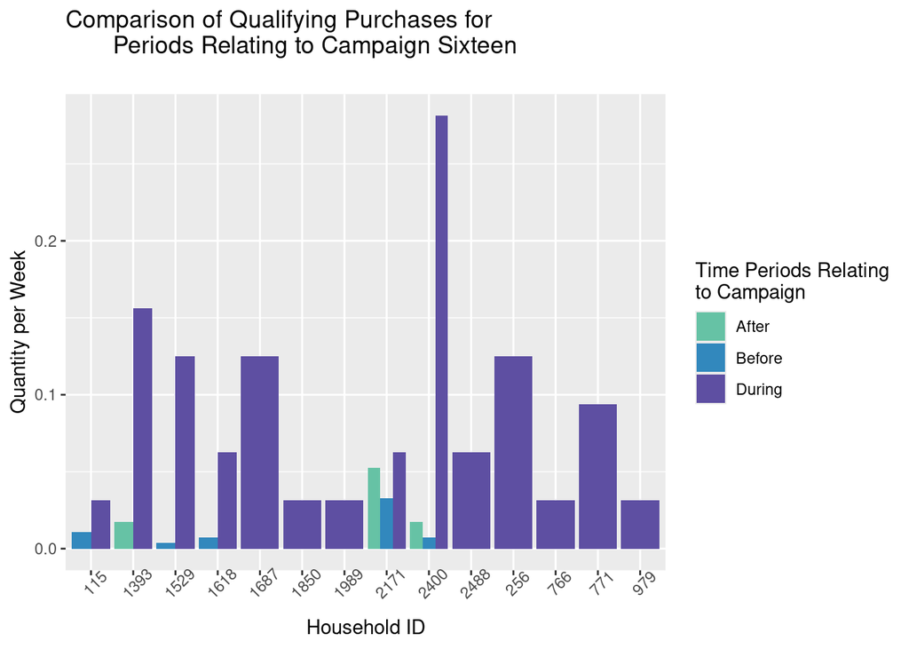

```r
# Now let's see if there is any relationship between the variables
# norm_quantity and per_rel_camp (using per_rel_id because it is numeric).
# We will find the correlation and test the null hypothesis that the two values # are not related to one another.
cor.test(all_cam16_tran_df$norm_quantity, all_cam16_tran_df$per_rel_num)
```

```
##
##  Pearson's product-moment correlation
##
## data:  all_cam16_tran_df$norm_quantity and all_cam16_tran_df$per_rel_num
## t = 0.8246, df = 20, p-value = 0.4193
## alternative hypothesis: true correlation is not equal to 0
## 95 percent confidence interval:
##  -0.2601695  0.5601165
## sample estimates:
##       cor
## 0.1813289
```

## Campaign 8

```r
# Let's look at the coupon data for campaign ID 8 (Type A)

# We can see that there are number of different product_ids associated with
# the various coupon_upcs attached to this campaign
coup_df <- coupons_df %>%
  select(campaign_id, product_id, coupon_upc) %>%
  group_by(campaign_id, coupon_upc) %>%
  filter(campaign_id == 8) %>%
  tally()

print.data.frame(coup_df)
```

```
##     campaign_id  coupon_upc    n
## 1             8 10000085361 4241
## 2             8 10000085362 3580
## 3             8 10000085363 4538
## 4             8 10000085364 1881
## 5             8 10000085365   12
## 6             8 10000085366  176
## 7             8 10000085367    1
## 8             8 10000085368    4
## 9             8 10000085369   12
## 10            8 10000089001   21
## 11            8 10000089002    1
## 12            8 10000089003    1
## 13            8 10000089004    1
## 14            8 10000089005    1
```

[output cut: 195 more lines]

```r
# Now, we want to see which households participated in this campaign. From
# there, we will examine how this correlates to the spending of those
# households both before and after the campaign.

# View purchases made by participating households during campaign 8
cam8_redem_df <- coupon_redemptions %>%
  select(campaign_id, household_id, coupon_upc, redemption_date) %>%
  filter(campaign_id == 8)

glimpse(cam8_redem_df)
```

```
## Rows: 372
## Columns: 4
## $ campaign_id     <chr> "8", "8", "8", "8", "8", "8", "8", "8", "8", "8", "8",…
## $ household_id    <chr> "1453", "2085", "2085", "2085", "2085", "239", "1083",…
## $ coupon_upc      <chr> "57457010076", "10000089029", "10000089040", "52100041…
## $ redemption_date <date> 2017-05-08, 2017-05-08, 2017-05-08, 2017-05-08, 2017-…
```

```r
# Let's see how many sale items each household purchased during the sale
# period

# First, merge redemption data with coupon data
cam8_coup_df <- merge(coupons_df, cam8_redem_df,
                       by = c("campaign_id","coupon_upc"))

# Next, merge redemption/coupon data with transaction data from the
# campaign period
cam8_tran_df <- merge(cam8_coup_df, transactions_df,
                       by = c("household_id", "product_id")) %>%
  select(household_id, product_id, quantity,
         redemption_date, transaction_timestamp) %>%
  filter(between(as.Date(transaction_timestamp), as.Date("2017-05-08"),
           as.Date("2017-06-25")),
         between(as.Date(redemption_date), as.Date("2017-05-08"),
           as.Date("2017-06-25")))

# Create a data file of the household IDs and product IDs that definitely
# have transactions within the campaign window. (Unfortunately, we cannot
# assume that all coupons in the redemption table have matches in the
# transaction table, and we want to make sure that we are not capturing
# transactions for any households that did not participate in the campaign.)
cam8_house_prod_df <- cam8_tran_df %>%
  distinct(household_id, product_id)

# Count the quantity of applicable products purchased during the campaign
# period per household
sum_cam8_tran_df <- cam8_tran_df %>%
  select(household_id, quantity) %>%
  group_by(household_id) %>%
  summarize(tot_quantity = sum(quantity))

# Normalize the quantity by determining quantity purchased per day;
# that way, we can accurately compare sales from before, during, and
# after the campaign period

# Get number of days in campaign
cam8_days <- as.numeric(difftime("2017-06-25", "2017-05-08", units = "days"))

print(cam8_days)
```

```
## [1] 48
```

```r
# Add the quantity per day field (norm_quantity) to the summary campaign
# data frame and add field showing period relative to campaign
sum_cam8_tran_df <- sum_cam8_tran_df %>%
  select(household_id, tot_quantity) %>%
  mutate(norm_quantity = (tot_quantity/cam8_days),
         per_rel_camp = "During",
         per_rel_num = 1)


# Show the quantity purchased and the quantity purchased per week by
# household # during the campaign period. Show only a portion of this data,
# though; since the campaign type is A, there are 209 coupon upc codes
# associated with # this campaign, as compared to 26, 14, and 13 coupon
# upc codes in the previous 3 campaigns, respectively.
glimpse(sum_cam8_tran_df)
```

```
## Rows: 151
## Columns: 5
## $ household_id  <chr> "1", "1005", "1015", "1024", "1029", "1064", "1066", "10…
## $ tot_quantity  <dbl> 16, 48, 1, 27, 14, 3, 5, 2, 69, 7, 1, 15, 2, 3, 3, 5, 22…
## $ norm_quantity <dbl> 0.33333333, 1.00000000, 0.02083333, 0.56250000, 0.291666…
## $ per_rel_camp  <chr> "During", "During", "During", "During", "During", "Durin…
## $ per_rel_num   <dbl> 1, 1, 1, 1, 1, 1, 1, 1, 1, 1, 1, 1, 1, 1, 1, 1, 1, 1, 1,…
```

```r
# Merge the redemption/coupon data with the transaction data from BEFORE
# the campaign period, and then merge that with the table of household
# IDs/product IDs that are participating in the campaign
pcam8_tran_df <- merge(cam8_coup_df, transactions_df,
                       by = c("household_id", "product_id")) %>%
  select(household_id, product_id, quantity, transaction_timestamp) %>%
  filter(as.Date(transaction_timestamp) < "2017-05-08")

pcam8_tran_df <- merge(pcam8_tran_df, cam8_house_prod_df,
                        by = c("household_id", "product_id"))

# Count the quantity of applicable products purchased before the campaign
# period per household
psum_cam8_tran_df <- pcam8_tran_df %>%
  select(household_id, quantity) %>%
  group_by(household_id) %>%
  summarize(tot_quantity = sum(quantity))

# Normalize the quantity value for the period before the campaign
pcam8_days <- as.numeric(difftime("2017-05-08", "2017-01-01", units = "days"))

print(pcam8_days)
```

```
## [1] 127
```

```r
# Add field to the summary campaign data frame showing the normalized
# quantity value, and add field showing period relative to campaign
psum_cam8_tran_df <- psum_cam8_tran_df %>%
  select(household_id, tot_quantity) %>%
  mutate(norm_quantity = (tot_quantity/pcam8_days),
         per_rel_camp = "Before",
         per_rel_num = 0)

# Again, view only a subset of the data from before the campaign period
glimpse(psum_cam8_tran_df)
```

```
## Rows: 135
## Columns: 5
## $ household_id  <chr> "1", "1005", "1015", "1024", "1029", "1064", "1066", "10…
## $ tot_quantity  <dbl> 25, 54, 1, 43, 20, 2, 5, 109, 8, 14, 3, 1, 4, 1, 8, 3, 5…
## $ norm_quantity <dbl> 0.196850394, 0.425196850, 0.007874016, 0.338582677, 0.15…
## $ per_rel_camp  <chr> "Before", "Before", "Before", "Before", "Before", "Befor…
## $ per_rel_num   <dbl> 0, 0, 0, 0, 0, 0, 0, 0, 0, 0, 0, 0, 0, 0, 0, 0, 0, 0, 0,…
```

```r
# Merge the redemption/coupon data with the transaction data from AFTER
# the campaign period, and then merge that with the table of household
# IDs/product IDs that are participating in the campaign
acam8_tran_df <- merge(cam8_coup_df, transactions_df,
                       by = c("household_id", "product_id")) %>%
  select(household_id, product_id, quantity, transaction_timestamp) %>%
  filter(as.Date(transaction_timestamp) > "2017-06-25")

acam8_tran_df <- merge(acam8_tran_df, cam8_house_prod_df,
                        by = c("household_id", "product_id"))

# Count the quantity of applicable products purchased after the campaign
# period per household
asum_cam8_tran_df <- acam8_tran_df %>%
  select(household_id, quantity) %>%
  group_by(household_id) %>%
  summarize(tot_quantity = sum(quantity))

# View a subset of the data from after the campaign period
glimpse(asum_cam8_tran_df)
```

```
## Rows: 132
## Columns: 2
## $ household_id <chr> "1", "1005", "1024", "1029", "1064", "1066", "1083", "109…
## $ tot_quantity <dbl> 44, 88, 39, 22, 2, 6, 1, 175, 4, 14, 9, 5, 3, 1, 14, 15, …
```

```r
# Normalize the quantity value for the period after the campaign
acam8_days <- as.numeric(difftime("2018-01-01", "2017-06-25", units = "days"))

print(acam8_days)
```

```
## [1] 190
```

```r
# Add field to the summary campaign data frame showing the normalized quantity
# value, and add field showing period relative to campaign
asum_cam8_tran_df <- asum_cam8_tran_df %>%
  select(household_id, tot_quantity) %>%
  mutate(norm_quantity = (tot_quantity/acam8_days),
         per_rel_camp = "After",
         per_rel_num = 2)

# View only a subset of the data from after the campaign period
glimpse(asum_cam8_tran_df)
```

```
## Rows: 132
## Columns: 5
## $ household_id  <chr> "1", "1005", "1024", "1029", "1064", "1066", "1083", "10…
## $ tot_quantity  <dbl> 44, 88, 39, 22, 2, 6, 1, 175, 4, 14, 9, 5, 3, 1, 14, 15,…
## $ norm_quantity <dbl> 0.231578947, 0.463157895, 0.205263158, 0.115789474, 0.01…
## $ per_rel_camp  <chr> "After", "After", "After", "After", "After", "After", "A…
## $ per_rel_num   <dbl> 2, 2, 2, 2, 2, 2, 2, 2, 2, 2, 2, 2, 2, 2, 2, 2, 2, 2, 2,…
```

### We have the rates at which the campaign products were purchased (quantity/day) for the periods before the campaign, during the campaign, and after the campaign. Now, let’s merge that data and observe it in a bar chart. From there, we can see if there are any statistical correlations to be drawn.

```r
#Join campaign transaction data with data from before the campaign
all_cam8_tran_df <- rbind(sum_cam8_tran_df, psum_cam8_tran_df)

#View a subset of the combined data
glimpse(all_cam8_tran_df)
```

```
## Rows: 286
## Columns: 5
## $ household_id  <chr> "1", "1005", "1015", "1024", "1029", "1064", "1066", "10…
## $ tot_quantity  <dbl> 16, 48, 1, 27, 14, 3, 5, 2, 69, 7, 1, 15, 2, 3, 3, 5, 22…
## $ norm_quantity <dbl> 0.33333333, 1.00000000, 0.02083333, 0.56250000, 0.291666…
## $ per_rel_camp  <chr> "During", "During", "During", "During", "During", "Durin…
## $ per_rel_num   <dbl> 1, 1, 1, 1, 1, 1, 1, 1, 1, 1, 1, 1, 1, 1, 1, 1, 1, 1, 1,…
```

```r
#Join campaign transaction data with data from after the campaign
all_cam8_tran_df <- rbind(all_cam8_tran_df, asum_cam8_tran_df)

#View a subset of the combined data
glimpse(all_cam8_tran_df)
```

```
## Rows: 418
## Columns: 5
## $ household_id  <chr> "1", "1005", "1015", "1024", "1029", "1064", "1066", "10…
## $ tot_quantity  <dbl> 16, 48, 1, 27, 14, 3, 5, 2, 69, 7, 1, 15, 2, 3, 3, 5, 22…
## $ norm_quantity <dbl> 0.33333333, 1.00000000, 0.02083333, 0.56250000, 0.291666…
## $ per_rel_camp  <chr> "During", "During", "During", "During", "During", "Durin…
## $ per_rel_num   <dbl> 1, 1, 1, 1, 1, 1, 1, 1, 1, 1, 1, 1, 1, 1, 1, 1, 1, 1, 1,…
```

### Display purchase rate for each household by time period relative to campaign period

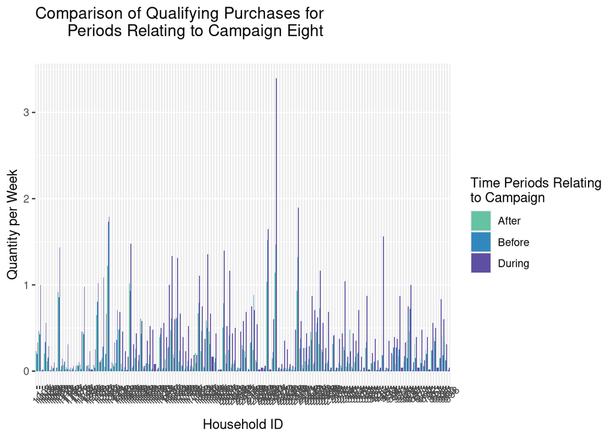

```
##
##  Pearson's product-moment correlation
##
## data:  all_cam8_tran_df$norm_quantity and all_cam8_tran_df$per_rel_num
## t = -0.65443, df = 416, p-value = 0.5132
## alternative hypothesis: true correlation is not equal to 0
## 95 percent confidence interval:
##  -0.12759210  0.06404259
## sample estimates:
##         cor
## -0.03206949
```

### The statistical analysis shows, as with the other campaigns, there does not seem to be a correlation between rate of purchase for the item(s) targeted in the campaign and the campaign period. The correlation coefficient is very low (-.03), and the we would need a p value of less than .05 to reject the hypothesis that there is NO relationship between the variables. Our p variable is .51. There are undoubtedly many other variables at play here, but I have not touched upon the ones that are correlating with one another.

### Since examining quantities of campaign products in relation to when they were purchased did not tell us much, let’s now look at demographic data related to the campaign products that were purchased during the campaign period. Although we do not have household data on all households (and therefore linking to households will limit the transactions data), that is an acceptable constraint since we want to examine household information in relation to transactional data. Specifically, we want to see if the quantity of sales items purchased has any statistically significant relationship to any demographic variables.

```r
# Build table of households/purchases again (because previous
# data frames were so heavily manipulated )

# View purchases made by participating households during campaign 8
cam8_redem_df2 <- coupon_redemptions %>%
  select(campaign_id, household_id, coupon_upc, redemption_date) %>%
  filter(campaign_id == 8)

glimpse(cam8_redem_df2)
```

```
## Rows: 372
## Columns: 4
## $ campaign_id     <chr> "8", "8", "8", "8", "8", "8", "8", "8", "8", "8", "8",…
## $ household_id    <chr> "1453", "2085", "2085", "2085", "2085", "239", "1083",…
## $ coupon_upc      <chr> "57457010076", "10000089029", "10000089040", "52100041…
## $ redemption_date <date> 2017-05-08, 2017-05-08, 2017-05-08, 2017-05-08, 2017-…
```

```r
# Let's see how many sale items each household purchased during the
# sale period

# First, merge redemption data with coupon data
cam8_coup_df2 <- merge(coupons_df, cam8_redem_df2,
                       by = c("campaign_id","coupon_upc"))

# Next, merge redemption/coupon data with transaction data from the
# campaign period
cam8_tran_df2 <- merge(cam8_coup_df2, transactions_df,
                       by = c("household_id", "product_id")) %>%
  select(household_id, product_id, quantity,
           redemption_date, transaction_timestamp) %>%
  filter(between(as.Date(transaction_timestamp), as.Date("2017-05-08"),
           as.Date("2017-06-25")),
         between(as.Date(redemption_date), as.Date("2017-05-08"),
           as.Date("2017-06-25")))

# Count the quantity of applicable products purchased during the
# campaign period per household
sum_cam8_tran_df2 <- cam8_tran_df2 %>%
  select(household_id, quantity) %>%
  group_by(household_id) %>%
  summarize(tot_quantity = sum(quantity))

# Normalize the quantity by determining quantity purchased per day;
# that way, we can accurately compare sales from before, during, and
# after the campaign period

cam8_days2 <- as.numeric(difftime("2017-06-25", "2017-05-08", units = "days"))

# Add field to the summary campaign data frame showing the normalized quantity
# value (which is quantity/days of period)
sum_cam8_tran_df2 <- sum_cam8_tran_df2 %>%
  select(household_id, tot_quantity) %>%
  mutate(norm_quantity = (tot_quantity/cam8_days2))


# Now that the household/products/transactions table has been rebuilt,
# join to demographics data
cam8_sum_hous_tran_df <- merge(sum_cam8_tran_df2, demo_df,
                                by = "household_id")

glimpse(cam8_sum_hous_tran_df)
```

```
## Rows: 113
## Columns: 10
## $ household_id   <chr> "1", "1015", "1024", "1066", "1113", "1146", "1166", "1…
## $ tot_quantity   <dbl> 16, 1, 27, 5, 7, 1, 2, 3, 3, 5, 22, 47, 11, 1, 12, 49, …
## $ norm_quantity  <dbl> 0.33333333, 0.02083333, 0.56250000, 0.10416667, 0.14583…
## $ age            <ord> 65+, 45-54, 25-34, 35-44, 45-54, 35-44, 45-54, 35-44, 6…
## $ income         <ord> 35-49K, 50-74K, Under 15K, 25-34K, 50-74K, 35-49K, 125-…
## $ home_ownership <ord> Homeowner, Homeowner, Homeowner, NA, Homeowner, Homeown…
## $ marital_status <ord> Married, Unmarried, Married, NA, Married, Unmarried, Ma…
## $ household_size <ord> 2, 1, 4, 2, 3, 4, 3, 4, 2, 2, 1, 2, 2, 3, 4, 4, 2, 4, 2…
## $ household_comp <ord> 2 Adults No Kids, 1 Adult No Kids, 2 Adults Kids, 2 Adu…
## $ kids_count     <ord> 0, 0, 2, 0, 1, 3+, 1, 2, 0, 1, 0, 0, 1, 2, 2, 2, 0, 2, …
```

### Let’s aggregate Campaign 8 data by age and income.

### Find the average quantity of product sold during the campaign, as well as the average daily sal rate, by: 1) age, 2) income, and 3) age and income

```r
demo_df %>% distinct(age)
```

```
## # A tibble: 6 × 1
##   age
##   <ord>
## 1 65+
## 2 45-54
## 3 35-44
## 4 25-34
## 5 55-64
## 6 19-24
```

```r
demo_df %>% distinct(income)
```

```
## # A tibble: 12 × 1
##    income
##    <ord>
##  1 35-49K
##  2 50-74K
##  3 25-34K
##  4 15-24K
##  5 Under 15K
##  6 75-99K
##  7 100-124K
##  8 125-149K
##  9 150-174K
## 10 250K+
## 11 175-199K
## 12 200-249K
```

```r
#Age

# Get the count of households, average quantity, and average
# daily quantity by age range
cam8_age_df <- cam8_sum_hous_tran_df %>%
  select(age, tot_quantity, norm_quantity, household_id) %>%
  mutate(house_ct = 1) %>%
  group_by(age) %>%
  summarize(avg_quant = mean(tot_quantity),
            avg_norm_quant = mean(norm_quantity),
            house_ct = sum(house_ct))
```

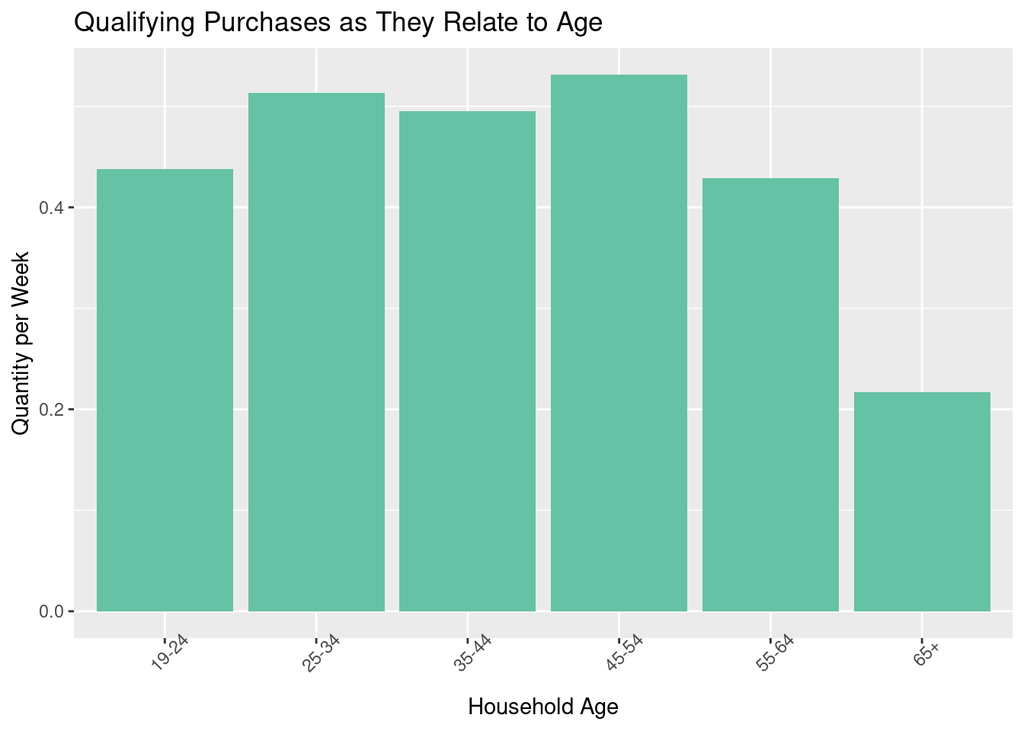

```r
# Let's look at statistics for age

# Get the total count of households
tot_house_age <- sum(cam8_age_df$house_ct)

print(tot_house_age)
```

```
## [1] 113
```

```r
# Display age range, average quanity, average daily quantity, and
# percentage of households
trunc_cam8_age_df <- cam8_age_df %>%
  select(age, avg_quant, avg_norm_quant, house_ct) %>%
  mutate(house_pct = house_ct/tot_house_age)

print.data.frame(trunc_cam8_age_df)
```

```
##     age avg_quant avg_norm_quant house_ct  house_pct
## 1 19-24  21.00000      0.4375000        2 0.01769912
## 2 25-34  24.64706      0.5134804       17 0.15044248
## 3 35-44  23.78125      0.4954427       32 0.28318584
## 4 45-54  25.48936      0.5310284       47 0.41592920
## 5 55-64  20.60000      0.4291667       10 0.08849558
## 6   65+  10.40000      0.2166667        5 0.04424779
```

```r
# Is there a statistical correlation between percentage of households
# at a specific age range and the average quantity per week purchased
# (product included in campaign)?
cor.test(as.numeric(trunc_cam8_age_df$house_pct),
         as.numeric(trunc_cam8_age_df$avg_norm_quant))
```

```
##
##  Pearson's product-moment correlation
##
## data:  as.numeric(trunc_cam8_age_df$house_pct) and as.numeric(trunc_cam8_age_df$avg_norm_quant)
## t = 1.638, df = 4, p-value = 0.1768
## alternative hypothesis: true correlation is not equal to 0
## 95 percent confidence interval:
##  -0.3663087  0.9544047
## sample estimates:
##       cor
## 0.6336149
```

```r
#Income

# Get the count of households, average quantity per week, and average
# quantity by income range
cam8_inc_df <- cam8_sum_hous_tran_df %>%
  select(income, tot_quantity, norm_quantity, household_id) %>%
  mutate(house_ct = 1,
         income_rank = case_when(income == "Under 15K" ~ 0,
                                 income == "15-24K" ~ 15,
                                 income == "25-34K" ~ 25,
                                 income == "35-49K" ~ 35,
                                 income == "50-74K" ~ 50,
                                 income == "75-99K" ~ 75,
                                 income == "100-124K" ~ 100,
                                 income == "125-149K" ~ 125,
                                 income == "150-174K" ~ 150,
                                 income == "175-199K" ~ 175,
                                 income == "250+" ~ 250)) %>%
  group_by(income, income_rank) %>%
  summarize(avg_quant = mean(tot_quantity),
            avg_norm_quant = mean(norm_quantity),
            house_ct = sum(house_ct))
```

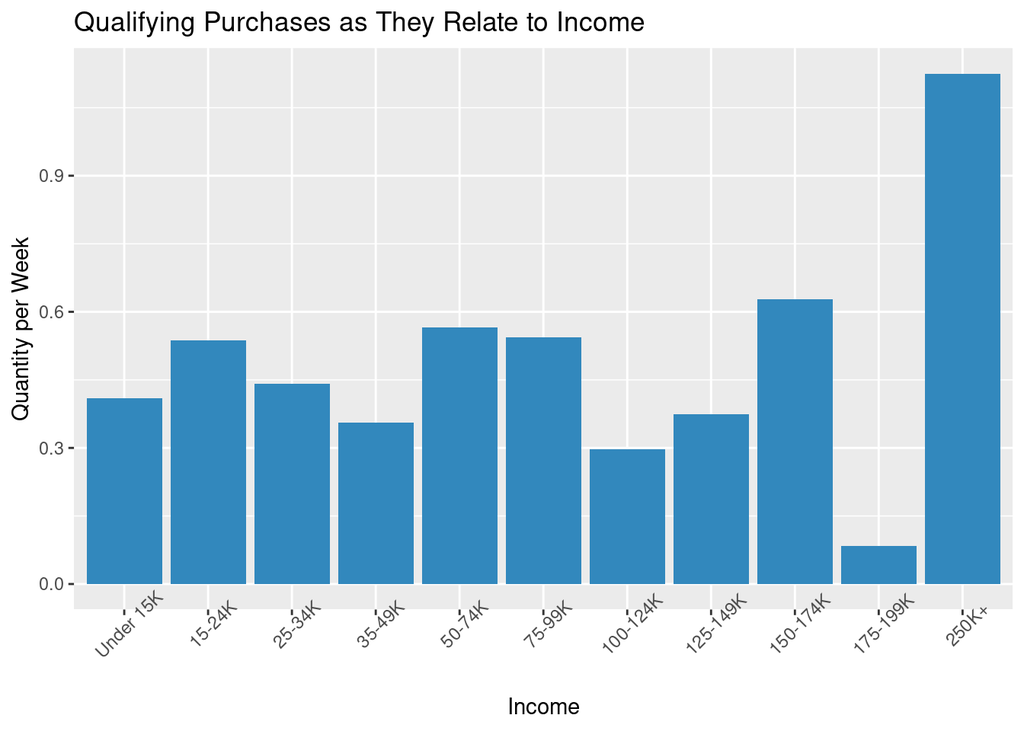

```r
# Let's look at statistics for income

# Get the total count of households
tot_house <- sum(cam8_inc_df$house_ct)

print(tot_house)
```

```
## [1] 113
```

```r
# Display income, average quanity, average quantity per week, and
# percentage of households
trunc_cam8_inc_df <- cam8_inc_df %>%
  select(income, avg_quant, avg_norm_quant, house_ct) %>%
  mutate(house_pct = house_ct/tot_house)

print.data.frame(trunc_cam8_inc_df)
```

```
##       income avg_quant avg_norm_quant house_ct   house_pct
## 1  Under 15K  19.66667     0.40972222        6 0.053097345
## 2     15-24K  25.75000     0.53645833        4 0.035398230
## 3     25-34K  21.22222     0.44212963        9 0.079646018
## 4     35-49K  17.10000     0.35625000       20 0.176991150
## 5     50-74K  27.17500     0.56614583       40 0.353982301
## 6     75-99K  26.08333     0.54340278       12 0.106194690
## 7   100-124K  14.25000     0.29687500        4 0.035398230
## 8   125-149K  18.00000     0.37500000        8 0.070796460
## 9   150-174K  30.14286     0.62797619        7 0.061946903
## 10  175-199K   4.00000     0.08333333        1 0.008849558
## 11     250K+  54.00000     1.12500000        2 0.017699115
```

```r
# Is there a statistical correlation between percentage of households
# at a specific income level and the average quantity per week
# purchased (product included in campaign)?
cor.test(as.numeric(trunc_cam8_inc_df$house_pct),
         as.numeric(trunc_cam8_inc_df$avg_norm_quant))
```

```
##
##  Pearson's product-moment correlation
##
## data:  as.numeric(trunc_cam8_inc_df$house_pct) and as.numeric(trunc_cam8_inc_df$avg_norm_quant)
## t = 0.072933, df = 9, p-value = 0.9435
## alternative hypothesis: true correlation is not equal to 0
## 95 percent confidence interval:
##  -0.5840867  0.6152096
## sample estimates:
##        cor
## 0.02430386
```

### The results of this statistical analysis say that no, there is no inherent correlation between the percent of households at a particular income level and the quantity of qualifying products that they would purchase. As the income was analyzed here, the various values were unranked, with no meaning behind them. They could have been values like A, B, or C, insead of 25-34K, 35-49K, or 50-74K. In other words, households at income level C were no more likely to make fewer or more qualifying purchases than households at income level B, perhaps because there was no *meanings* or *rankings* tied to the analysis of those incomes.

```r
# Income/Age

# Get the count of households, average quantity per week, average
# quantity by age group and income group
cam8_inc_age_df <- cam8_sum_hous_tran_df %>%
  select(age, income, tot_quantity, norm_quantity, household_id) %>%
  mutate(house_ct = 1) %>%
  group_by(age, income) %>%
  summarize(avg_quant = mean(tot_quantity),
            avg_norm_quant = mean(norm_quantity),
            house_ct = sum(house_ct))
```

[output not shown]

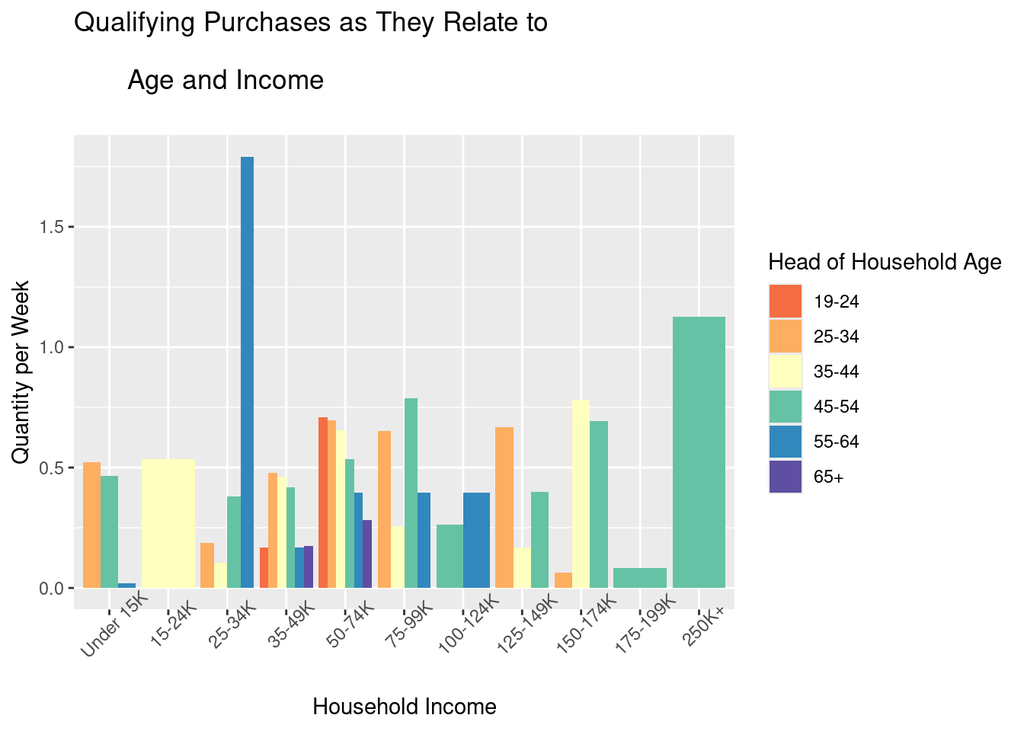

```r
# Get the count of households, average quantity per week, average
# quantity, and average income rank by age group
cam8_inc_age_df2 <- cam8_sum_hous_tran_df %>%
  select(age, income, tot_quantity, norm_quantity, household_id) %>%
  mutate(house_ct = 1,
    income_rank = case_when(income == "Under 15K" ~ 0,
                                 income == "15-24K" ~ 15,
                                 income == "25-34K" ~ 25,
                                 income == "35-49K" ~ 35,
                                 income == "50-74K" ~ 50,
                                 income == "75-99K" ~ 75,
                                 income == "100-124K" ~ 100,
                                 income == "125-149K" ~ 125,
                                 income == "150-174K" ~ 150,
                                 income == "175-199K" ~ 175,
                                 income == "200-249K" ~ 200,
                                 income == "250+" ~ 250)) %>%
  group_by(age) %>%
  summarize(avg_quant = mean(tot_quantity),
            avg_norm_quant = mean(norm_quantity),
            avg_inc_rank = mean(income_rank),
            house_ct = sum(house_ct))

glimpse(cam8_inc_age_df2)
```

```
## Rows: 6
## Columns: 5
## $ age            <ord> 19-24, 25-34, 35-44, 45-54, 55-64, 65+
## $ avg_quant      <dbl> 21.00000, 24.64706, 23.78125, 25.48936, 20.60000, 10.40…
## $ avg_norm_quant <dbl> 0.4375000, 0.5134804, 0.4954427, 0.5310284, 0.4291667, …
## $ avg_inc_rank   <dbl> 42.50000, 52.64706, 54.68750, NA, 45.50000, 41.00000
## $ house_ct       <dbl> 2, 17, 32, 47, 10, 5
```

```r
# Let's look at statistics for age/income

# Get the total count of households
tot_house <- sum(cam8_inc_df$house_ct)

print(tot_house)
```

```
## [1] 113
```

```r
# Display average income rank, average quanity, average quantity per
# week, and percentage of households
trunc_cam8_inc_age_df <- cam8_inc_age_df2 %>%
  select(avg_inc_rank, avg_quant, avg_norm_quant, house_ct) %>%
  mutate(house_pct = house_ct/tot_house)

print.data.frame(trunc_cam8_inc_age_df)
```

```
##   avg_inc_rank avg_quant avg_norm_quant house_ct  house_pct
## 1     42.50000  21.00000      0.4375000        2 0.01769912
## 2     52.64706  24.64706      0.5134804       17 0.15044248
## 3     54.68750  23.78125      0.4954427       32 0.28318584
## 4           NA  25.48936      0.5310284       47 0.41592920
## 5     45.50000  20.60000      0.4291667       10 0.08849558
## 6     41.00000  10.40000      0.2166667        5 0.04424779
```

```r
# Is there a statistical correlation between average income rank at a
# specific age and the average quantity per week purchased (product
# included in campaign)?
cor.test(as.numeric(trunc_cam8_inc_age_df$avg_inc_rank),
         as.numeric(trunc_cam8_inc_age_df$avg_norm_quant))
```

```
##
##  Pearson's product-moment correlation
##
## data:  as.numeric(trunc_cam8_inc_age_df$avg_inc_rank) and as.numeric(trunc_cam8_inc_age_df$avg_norm_quant)
## t = 2.1116, df = 3, p-value = 0.1252
## alternative hypothesis: true correlation is not equal to 0
## 95 percent confidence interval:
##  -0.3432113  0.9841246
## sample estimates:
##       cor
## 0.7731757
```

### The answers to this question is no, based on the data; the correlation coefficient between the average income rank in a certain age range and the average quantity of qualifying purchases is .773, with a p value of .125. As the bar graphs show, and the data in the table below shows, this campaign was a hit with 2 households in the $250,000+ income and with one household in particular that fell in the $25,000 - $34,000 income range and also in the 55 to 64 year age range.

```r
# Select count of households, average quantity purchased, and average
# quantity per week purchased by age range and income range for products
# included in campaign 8
cam8_age_df1 <- cam8_sum_hous_tran_df %>%
  select(age, income, tot_quantity, norm_quantity, household_id) %>%
  mutate(house_ct = 1) %>%
  group_by(age, income) %>%
  summarize(avg_quant = mean(tot_quantity),
            avg_norm_quant = mean(norm_quantity),
            house_ct = sum(house_ct))
```

[output not shown]

```r
print.data.frame(cam8_age_df1)
```

```
##      age    income avg_quant avg_norm_quant house_ct
## 1  19-24    35-49K  8.000000     0.16666667        1
## 2  19-24    50-74K 34.000000     0.70833333        1
## 3  25-34 Under 15K 25.000000     0.52083333        2
## 4  25-34    25-34K  9.000000     0.18750000        3
## 5  25-34    35-49K 23.000000     0.47916667        2
## 6  25-34    50-74K 33.400000     0.69583333        5
## 7  25-34    75-99K 31.333333     0.65277778        3
## 8  25-34  125-149K 32.000000     0.66666667        1
## 9  25-34  150-174K  3.000000     0.06250000        1
## 10 35-44    15-24K 25.750000     0.53645833        4
## 11 35-44    25-34K  5.000000     0.10416667        1
## 12 35-44    35-49K 22.111111     0.46064815        9
## 13 35-44    50-74K 31.400000     0.65416667       10
## 14 35-44    75-99K 12.250000     0.25520833        4
```

[output cut: 20 more lines]